# Level2_11

```python
from google.colab import drive
drive.mount('/content/drive/')
```

```python
import os

path = os.getcwd()

try:
  os.chdir(path + '/drive/My Drive/QC_Kentei')
except:
  pass

os.getcwd()
```

```
'/content/drive/My Drive/QC_Kentei'
```

```python
!pip install japanize-matplotlib
!pip install gspread pandas gspread-dataframe
```

```python
from gspread_dataframe import set_with_dataframe
import gspread

# 認証のためのコード
from google.colab import auth
auth.authenticate_user()

from google.auth import default
creds, _ = default()

gc = gspread.authorize(creds)
```

## 11.1

$ H_0 : \mu = \mu_0 \qquad (\mu_0 = 100) $

$ H_1 : \mu > \mu_0 $

$ \alpha = 0.05 $

$ R : \mu_0 \geq u(2 \alpha) = u(0.10) = 1.645 $

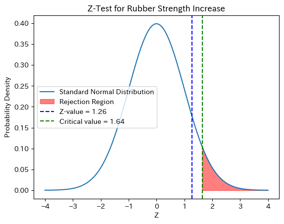

```python
import numpy as np
import matplotlib.pyplot as plt
from scipy import stats

# データの設定
sample_mean = 102
population_mean = 100
population_std = 5
n = 10

# Z検定の統計量の計算
z_value = (sample_mean - population_mean) / (population_std / np.sqrt(n))

# 有意水準と臨界値
alpha = 0.05
critical_value = stats.norm.ppf(1 - alpha)

# 標準正規分布のプロット
x = np.linspace(-4, 4, 1000)
y = stats.norm.pdf(x)

plt.plot(x, y, label='Standard Normal Distribution')
plt.fill_between(x, 0, y, where=(x > critical_value), color='red', alpha=0.5, label='Rejection Region')
plt.axvline(z_value, color='blue', linestyle='--', label=f'Z-value = {z_value:.2f}')
plt.axvline(critical_value, color='green', linestyle='--', label=f'Critical value = {critical_value:.2f}')

plt.title('Z-Test for Rubber Strength Increase')
plt.xlabel('Z')
plt.ylabel('Probability Density')
plt.legend()
plt.show()
```

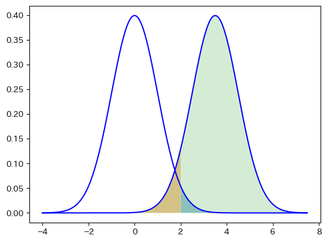

```python
import numpy as np
from scipy.stats import norm
import scipy.stats as stats

# 平均と標準偏差の設定
mean_weight = 0
mean_weight2 = 3.5
std_dev_weight = 1
std_dev_weight2 = 1

#図を描画する範囲を指定
start = mean_weight - std_dev_weight * 4 #xの左側 (μ-4σ)
end = mean_weight2 + std_dev_weight2 * 4 #xの右側 (μ+4σ)

x =np.arange(start,end, 0.01) #xの値を生成
# 確率密度関数を生成
y1 = norm.pdf(x, loc=mean_weight, scale=std_dev_weight)
y2 =0
y11 = norm.pdf(x, loc=mean_weight2, scale=std_dev_weight2)
y22 = 0

x2 = np.linspace(1,2,100)
y3 = norm.pdf(x2, loc=mean_weight, scale=std_dev_weight)
y4 = 0
x22 = np.linspace(1,2,100)
y33 = norm.pdf(x2, loc=mean_weight2, scale=std_dev_weight2)
y44 = 0

plt.plot(x, y1, c="b") #正規分布を描画
plt.plot(x, y11, c="b") #正規分布を描画

plt.fill_between(x, y1, y2, where=(x>2), alpha=0.4)
plt.fill_between(x, y11, y22, where=(x<2), alpha=0.4)
plt.fill_between(x, y11, y22, alpha=0.2)
# plt.fill_between(x2, y3, y4, alpha=0.4)

plt.savefig("Graph2/DistribuciónNorma.png", format="png", dpi=300)
```

## 11.2

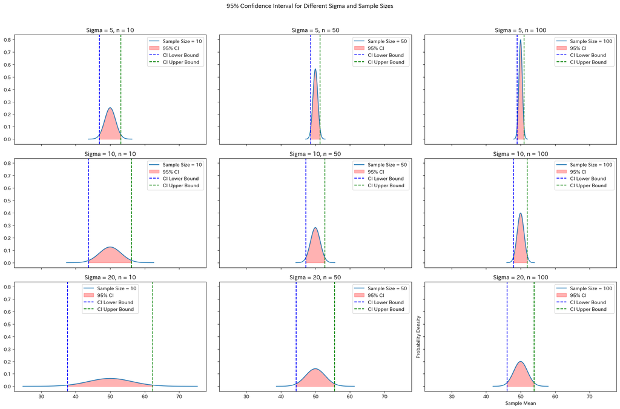

```python
import numpy as np
import matplotlib.pyplot as plt
from scipy import stats

# パラメータの設定
mu = 50  # 母平均
sigma_values = [5, 10, 20]  # 異なる母標準偏差の値
sample_sizes = [10, 50, 100]  # 異なるサンプルサイズの値

# 信頼区間を計算する関数
def confidence_interval(mean, sigma, n, confidence=0.95):
    z = stats.norm.ppf(1 - (1 - confidence) / 2)
    margin_of_error = z * (sigma / np.sqrt(n))
    return (mean - margin_of_error, mean + margin_of_error)

# グラフの設定
fig, axs = plt.subplots(len(sigma_values), len(sample_sizes), figsize=(18, 12), sharex=True, sharey=True)

for i, sigma in enumerate(sigma_values):
    for j, n in enumerate(sample_sizes):
        mean = mu
        lower, upper = confidence_interval(mean, sigma, n)
        x = np.linspace(mean - 4*sigma/np.sqrt(n), mean + 4*sigma/np.sqrt(n), 1000)
        y = stats.norm.pdf(x, loc=mean, scale=sigma/np.sqrt(n))

        axs[i, j].plot(x, y, label=f'Sample Size = {n}')
        axs[i, j].fill_between(x, 0, y, where=(x >= lower) & (x <= upper), color='red', alpha=0.3, label='95% CI')
        axs[i, j].axvline(lower, color='blue', linestyle='--', label=f'CI Lower Bound')
        axs[i, j].axvline(upper, color='green', linestyle='--', label=f'CI Upper Bound')

        axs[i, j].set_title(f'Sigma = {sigma}, n = {n}')
        axs[i, j].legend()

plt.suptitle('95% Confidence Interval for Different Sigma and Sample Sizes')
plt.xlabel('Sample Mean')
plt.ylabel('Probability Density')
plt.tight_layout(rect=[0, 0, 1, 0.96])
plt.show()
```

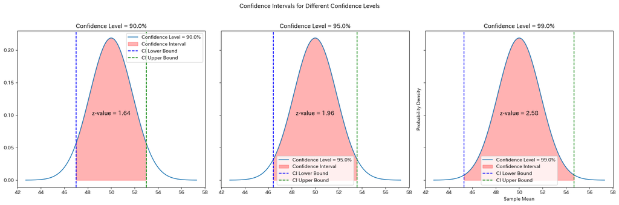

```python
import numpy as np
import matplotlib.pyplot as plt
from scipy import stats

# パラメータの設定
mu = 50  # 母平均
sigma = 10  # 母標準偏差
n = 30  # サンプルサイズ
confidence_levels = [0.90, 0.95, 0.99]  # 信頼率

# 信頼区間を計算する関数
def confidence_interval(mean, sigma, n, confidence):
    z = stats.norm.ppf(1 - (1 - confidence) / 2)
    margin_of_error = z * (sigma / np.sqrt(n))
    return (mean - margin_of_error, mean + margin_of_error), z

# グラフの設定
fig, axs = plt.subplots(1, len(confidence_levels), figsize=(18, 6), sharex=True, sharey=True)

for i, confidence in enumerate(confidence_levels):
    mean = mu
    (lower, upper), z_value = confidence_interval(mean, sigma, n, confidence)
    x = np.linspace(mean - 4*sigma/np.sqrt(n), mean + 4*sigma/np.sqrt(n), 1000)
    y = stats.norm.pdf(x, loc=mean, scale=sigma/np.sqrt(n))

    axs[i].plot(x, y, label=f'Confidence Level = {confidence*100}%')
    axs[i].fill_between(x, 0, y, where=(x >= lower) & (x <= upper), color='red', alpha=0.3, label='Confidence Interval')
    axs[i].axvline(lower, color='blue', linestyle='--', label=f'CI Lower Bound')
    axs[i].axvline(upper, color='green', linestyle='--', label=f'CI Upper Bound')
    axs[i].text(mean, 0.1, f'z-value = {z_value:.2f}', horizontalalignment='center', fontsize=12, color='black')

    axs[i].set_title(f'Confidence Level = {confidence*100}%')
    axs[i].legend()

plt.suptitle('Confidence Intervals for Different Confidence Levels')
plt.xlabel('Sample Mean')
plt.ylabel('Probability Density')
plt.tight_layout(rect=[0, 0, 1, 0.96])
plt.show()
```

## 11.3

仮説の設定と有意水準

$ H_0 : \sigma^2 = \sigma_0^2 \qquad (\sigma_0^2 = 6^2) $

$ H_1 : \sigma^2 < \sigma_0^2 $

$ \alpha = 0.05$

棄却域の設定

検定統計量の計算

$ \chi_0^2 = \frac{S}{\sigma_0^2} = \frac{(n-1)V}{\sigma_0^2} = 2.0 $

点推定

$ \hat{\sigma}^2 = V = \frac{S}{n-1} $

信頼率95％の区間推定

$ \sigma_U^2 = \frac{S}{\chi^2 (8, 0.975)} = 33.0 $

$ \sigma_L^2 = \frac{S}{\chi^2(8, 0.025)} = 4.1 $

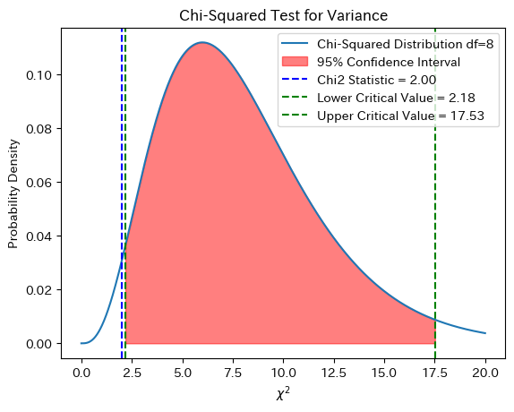

```
Valor del estadístico de prueba: 2.00
Punto crítico de la región de rechazo: 2.18
Conclusión: La hipótesis nula es rechazada
Intervalo de confianza del 95%: (2.18, 17.53)
```

```python
import numpy as np
import matplotlib.pyplot as plt
from scipy.stats import chi2

# 元のデータ
mu_0 = 50
sigma_0 = np.sqrt(36)
n = 9

# 改善後の試作品データ
xbar = 51
s2 = 9

# χ二乗検定の統計量の計算
chi2_statistic = (n - 1) * s2 / (sigma_0 ** 2)

# 自由度
df = n - 1

# 95%信頼区間の計算
alpha = 0.05
chi2_lower = chi2.ppf(alpha / 2, df)
chi2_upper = chi2.ppf(1 - alpha / 2, df)

# 95%信頼区間の境界
confidence_interval_lower = (df * s2) / chi2_upper
confidence_interval_upper = (df * s2) / chi2_lower

# 結果の表示
chi2_statistic, chi2_lower, chi2_upper, confidence_interval_lower, confidence_interval_upper

# χ二乗分布のプロット
x = np.linspace(0, 20, 1000)
y = chi2.pdf(x, df)

plt.plot(x, y, label=f'Chi-Squared Distribution df={df}')
plt.fill_between(x, 0, y, where=(x >= chi2_lower) & (x <= chi2_upper), color='red', alpha=0.5, label='95% Confidence Interval')
plt.axvline(chi2_statistic, color='blue', linestyle='--', label=f'Chi2 Statistic = {chi2_statistic:.2f}')
plt.axvline(chi2_lower, color='green', linestyle='--', label=f'Lower Critical Value = {chi2_lower:.2f}')
plt.axvline(chi2_upper, color='green', linestyle='--', label=f'Upper Critical Value = {chi2_upper:.2f}')

plt.title('Chi-Squared Test for Variance')
plt.xlabel('$\chi^2$')
plt.ylabel('Probability Density')
plt.legend()
plt.show()

reject_H0 = chi2_statistic < chi2_lower

print(f"Valor del estadístico de prueba: {chi2_statistic:.2f}")
print(f"Punto crítico de la región de rechazo: {chi2_lower:.2f}")
print("Conclusión: La hipótesis nula " + ("es rechazada" if reject_H0 else "no es rechazada"))
print(f"Intervalo de confianza del 95%: ({chi2_lower:.2f}, {chi2_upper:.2f})")
```

## 11.4

$ H_0 : \mu = \mu_0 \qquad (\mu_0 = 50) $

$ H_1 : \mu > \mu_0 $

$ \alpha = 0.05 $

$ R : u_0 \ge u(2\alpha) = u(0.10) $

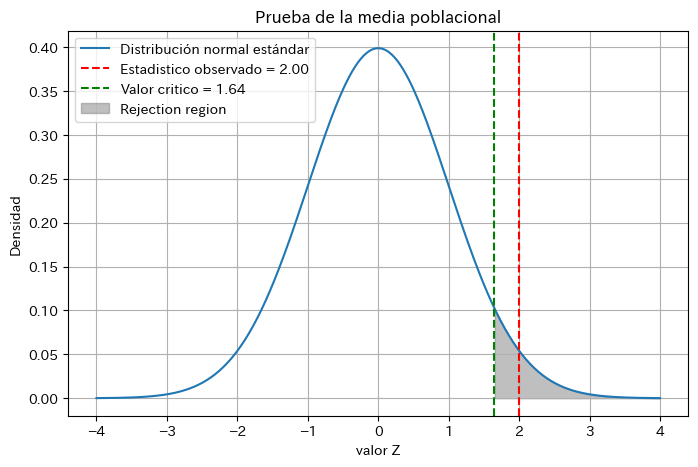

```
Valor del estadistico de prueba: 2.00
Valor critico de la región de rechazo: 1.645
Conclusión: la hipótesis nuela es rechazada
```

```python
import numpy as np
import matplotlib.pyplot as plt
from scipy.stats import norm

# 元のデータ
mu_0 = 50
sigma_0 = np.sqrt(36)
n = 9

# 改善後の試作品データ
xbar = 54

# 有意水準
alpha = 0.05

# 検定統計量の計算
z = (xbar - mu_0) / (sigma_0 / np.sqrt(n))

# 棄却域の計算
z_critical = norm.ppf(1 - alpha)

# 結論
reject_H0 = z > z_critical

# グラフの作成
x = np.linspace(-4, 4, 400)
z_dist = norm.pdf(x, 0, 1)

plt.figure(figsize=(8, 5))
plt.plot(x, z_dist, label='Distribución normal estándar')
plt.axvline(z, color='r', linestyle='--', label=f'Estadistico observado = {z:.2f}')
plt.axvline(z_critical, color='g', linestyle='--', label=f'Valor critico = {z_critical:.2f}')
plt.fill_between(x, 0, z_dist, where=(x > z_critical), color='gray', alpha=0.5, label='Rejection region')
plt.title('Prueba de la media poblacional')
plt.xlabel('valor Z')
plt.ylabel('Densidad')
plt.legend()
plt.grid(True)
plt.show()

print(f"Valor del estadistico de prueba: {z:.2f}")
print(f"Valor critico de la región de rechazo: {z_critical:.3f}")
print("Conclusión: la hipótesis nuela " + ("es rechazada" if reject_H0 else "no es rechazada"))
```

## 11.5

$ H_0 : \mu = \mu_0 \qquad (\mu_0 = 50) $

$ H_1 : \mu > \mu_0 $

$ \alpha = 0.05 $

$ R : t_0 \ge t(\phi ,2\alpha) = t(n-1, 0.10) $

```
Estadistico t: 4.00
Valor critico t: 1.86
La hipótesis nula es rechazada, se considera que hubo un efecto de mejora
Intervalo de confianza（95%）: [51.7 56.3]
P value 0.0039
```

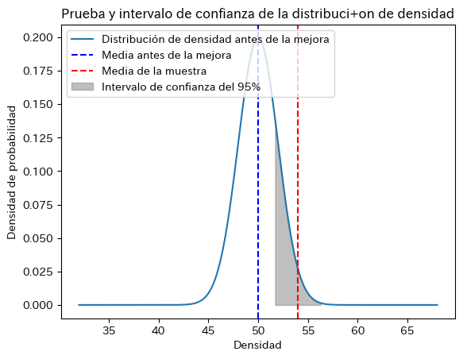

```python
import numpy as np
import scipy.stats as stats
import matplotlib.pyplot as plt

# データの定義
mu_0 = 50      # 改善前の母平均
sigma_0 = np.sqrt(36)  # 改善前の母標準偏差
n = 9         # サンプルサイズ
x_bar = 54    # サンプル平均
s = np.sqrt(9)  # サンプル標準偏差
alpha = 0.05  # 有意水準

# t検定の実行
t_stat = (x_bar - mu_0) / (s / np.sqrt(n))
t_critical = stats.t.ppf(1 - alpha, df=n-1)

# 結果の表示
print(f"Estadistico t: {t_stat:.2f}")
print(f"Valor critico t: {t_critical:.2f}")

if t_stat > t_critical:
    print("La hipótesis nula es rechazada, se considera que hubo un efecto de mejora")
else:
    print("La hipótesis nula no es rechazada, se considera que no hubo efecto que no hubo efecto de mejora")

# 信頼区間の計算
confidence_level = 0.95
t_value = stats.t.ppf((1 + confidence_level) / 2, df=n-1)
margin_of_error = t_value * (s / np.sqrt(n))
confidence_interval = (x_bar - margin_of_error, x_bar + margin_of_error)
confidence_interval = np.round(confidence_interval,1)
print(f"Intervalo de confianza（95%）: {confidence_interval}")

# t検定の統計量の計算
t_statistic = (x_bar - mu_0) / (s / np.sqrt(n))

# 自由度
df = n - 1

# p値の計算（両側検定）
p_value = 2 * (1 - stats.t.cdf(abs(t_statistic), df))
print(f"P value {p_value:.4f}")

# グラフの作成
x = np.linspace(mu_0 - 3*sigma_0, mu_0 + 3*sigma_0, 1000)
y = stats.norm.pdf(x, mu_0, sigma_0/np.sqrt(n))

plt.plot(x, y, label="Distribución de densidad antes de la mejora")
plt.axvline(x=mu_0, color='blue', linestyle='--', label="Media antes de la mejora")
plt.axvline(x=x_bar, color='red', linestyle='--', label="Media de la muestra")
plt.fill_between(x, 0, y, where=(x > confidence_interval[0]) & (x < confidence_interval[1]), color='gray', alpha=0.5, label="Intervalo de confianza del 95%")

plt.title("Prueba y intervalo de confianza de la distribuci+on de densidad")
plt.xlabel("Densidad")
plt.ylabel("Densidad de probabilidad")
plt.legend(loc='upper left')
plt.show()
```

## 11.6-1

$ H0 : \mu_A = \mu_B $

$ H1 : \mu_A \neq \mu_B $

$ t_0 = \frac{\bar{x}_A -\bar{x}_B}{\sqrt{V(\frac{1}{n_A} + \frac{1}{n_B})}} $ ただし $ V = \frac{S_A + S_B}{n_A + n_B -2} $

```
t-statistic: 1.2725698166200137, p-value: 0.20824865119076585
```

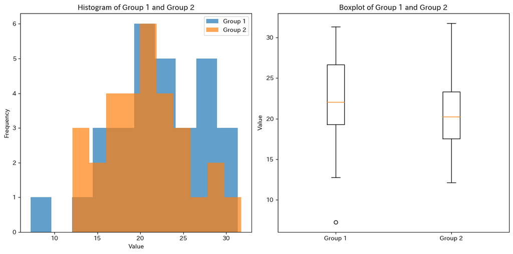

```python
import numpy as np
import scipy.stats as stats
import matplotlib.pyplot as plt

# データ生成
np.random.seed(0)
mu1, sigma1, n1 = 20, 5, 30  # グループ1の平均、標準偏差、サンプル数
mu2, sigma2, n2 = 22, 5, 30  # グループ2の平均、標準偏差、サンプル数

group1 = np.random.normal(mu1, sigma1, n1)
group2 = np.random.normal(mu2, sigma2, n2)

df = pd.DataFrame({'Group 1': group1, 'Group 2': group2})
df.to_excel('Data2/11_6-1.xlsx')

# 独立二標本t検定
t_stat, p_value = stats.ttest_ind(group1, group2, equal_var=True)
print(f't-statistic: {t_stat}, p-value: {p_value}')

# グラフの描画
plt.figure(figsize=(12, 6))

# ヒストグラム
plt.subplot(1, 2, 1)
plt.hist(group1, bins=10, alpha=0.7, label='Group 1')
plt.hist(group2, bins=10, alpha=0.7, label='Group 2')
plt.legend(loc='upper right')
plt.title('Histogram of Group 1 and Group 2')
plt.xlabel('Value')
plt.ylabel('Frequency')

# 箱ひげ図
plt.subplot(1, 2, 2)
plt.boxplot([group1, group2], labels=['Group 1', 'Group 2'])
plt.title('Boxplot of Group 1 and Group 2')
plt.ylabel('Value')

plt.tight_layout()
plt.show()
```

```python
url  = "https://docs.google.com/spreadsheets/d/1a_qscrI6712-9-6XhA1bc5rURnvaeXKKpuXhO8grv6c/edit?usp=drive_link"
ss = gc.open_by_url(url)


# データを取得する。（リストとして）
st = ss.worksheet("Sheet1")
list_of_lists = st.get_all_values()
df = pd.DataFrame(list_of_lists)

# 1行目を列名に設定
df.columns = df.iloc[0]
# 1行目を削除
df = df.drop(df.index[0])

# インデックスをリセット
df.reset_index(drop=True, inplace=True)

# 数値に変換する関数
def convert_to_numeric(df):
    for col in df.columns:
        df[col] = pd.to_numeric(df[col], errors='coerce')
    return df


df = convert_to_numeric(df)
df = df.drop(df.columns[0], axis=1)

# 対応のあるt検定
t_stat, p_value = stats.ttest_ind(df['Group 1'], df['Group 2'])
print(f't-statistic: {t_stat}, p-value: {p_value}')


worksheet = ss.get_worksheet(1)  # 0は最初のワークシートを指します

# DataFrameをGoogle Sheetsに書き出す
set_with_dataframe(worksheet, df)
```

```
t-statistic: 1.2725698172970619, p-value: 0.20824865095205514
```

## 11.6-2

対応のあるデータの場合

$ H_0 : \mu_A = \mu_B $

$ H_1 : \mu_A \neq \mu_B $

$ t_0 = \frac{\bar{d}}{\sqrt{V_d / n}} $

```
t-statistic: -1.7848794771059635, p-value: 0.10794104681485403
```

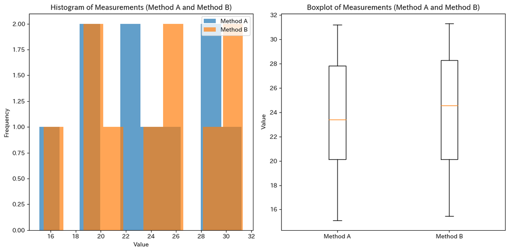

```python
import numpy as np
import scipy.stats as stats
import matplotlib.pyplot as plt

# データ生成
np.random.seed(0)
# 10ロットのサンプルデータ
sample_size = 10
# A法の測定値（例としてランダムなデータを生成）
measurements_A = np.random.normal(20, 5, sample_size)
# B法の測定値（例としてA法に対して少しずらしたデータを生成）
measurements_B = measurements_A + np.random.normal(0, 1, sample_size)

df = pd.DataFrame({'A': measurements_A, 'B': measurements_B})
df.to_excel('Data2/11_6-2.xlsx')

# 対応のあるt検定
t_stat, p_value = stats.ttest_rel(measurements_A, measurements_B)
print(f't-statistic: {t_stat}, p-value: {p_value}')

# グラフの描画
plt.figure(figsize=(12, 6))

# ヒストグラム
plt.subplot(1, 2, 1)
plt.hist(measurements_A, bins=10, alpha=0.7, label='Method A')
plt.hist(measurements_B, bins=10, alpha=0.7, label='Method B')
plt.legend(loc='upper right')
plt.title('Histogram of Measurements (Method A and Method B)')
plt.xlabel('Value')
plt.ylabel('Frequency')

# 箱ひげ図
plt.subplot(1, 2, 2)
plt.boxplot([measurements_A, measurements_B], labels=['Method A', 'Method B'])
plt.title('Boxplot of Measurements (Method A and Method B)')
plt.ylabel('Value')

plt.tight_layout()
plt.show()
```

```python
url = "https://docs.google.com/spreadsheets/d/1coIVibdqPPnVgFh_f-iea3IsHXRxVhtEhuzdYjEHCYg/edit?usp=drive_link"
ss = gc.open_by_url(url)


# データを取得する。（リストとして）
st = ss.worksheet("Sheet1")
list_of_lists = st.get_all_values()
df = pd.DataFrame(list_of_lists)

# 1行目を列名に設定
df.columns = df.iloc[0]
# 1行目を削除
df = df.drop(df.index[0])

# インデックスをリセット
df.reset_index(drop=True, inplace=True)

# 数値に変換する関数
def convert_to_numeric(df):
    for col in df.columns:
        df[col] = pd.to_numeric(df[col], errors='coerce')
    return df


df = convert_to_numeric(df)
df = df.drop(df.columns[0], axis=1)

# 対応のあるt検定
t_stat, p_value = stats.ttest_rel(df['A'], df['B'])
print(f't-statistic: {t_stat}, p-value: {p_value}')

worksheet = ss.get_worksheet(1)  # 0は最初のワークシートを指します

# DataFrameをGoogle Sheetsに書き出す
set_with_dataframe(worksheet, df)
```

```
t-statistic: -1.7848794687357996, p-value: 0.1079410482423603
```

## 11.7-1

$ H_0 : P = P_0 $ ただし、 $ (P_0 = 0.050) $

$ H_1 : P \neq P_0 $

$ \alpha = 0.05 $

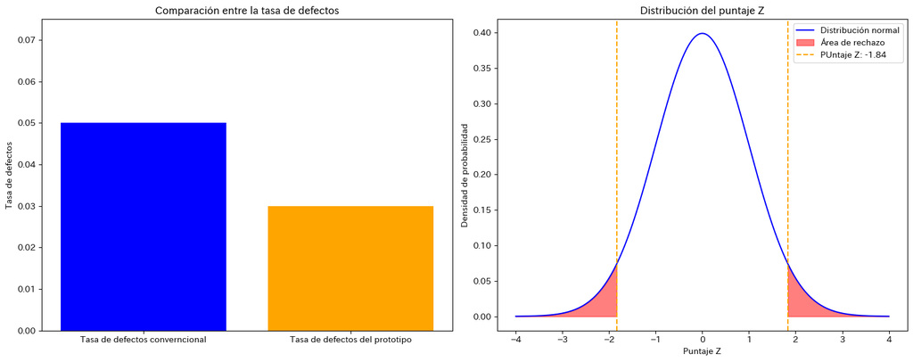

```
Áreade rechaso: 1.960
Tasa de defectos del prototipo: 0.0300
Error estándar: 0.0109
Puntaje Z: -1.8353
Valor P: 0.0665
No rechazo la hipótesis nula. No hay diferencia entre la nueva tasa de defectos y la tasa de defectos anterior.
```

```python
import matplotlib.pyplot as plt
import numpy as np
import scipy.stats as stats

# Tasa de defectos anterior
p_old = 0.05  # Número de muestras probadas
n = 400       # Número de muestras probadas
x_new = 12    # Número de defectos

alpha = 0.05

# Tasa de defectos del prototipo
p_new = x_new / n

# Cáluculo del error estándar
standard_error = (p_old * (1 - p_old) / n) ** 0.5

# Cáluculo del puntaje Z
z_score = (p_new - p_old) / standard_error

# Cálculo del valor P de la prueba bilateral
p_value = 2 * (1 - stats.norm.cdf(abs(z_score)))

# Cáluculo del área de rechazo
z_critical = stats.norm.ppf(1-alpha/2)

result_text = (
    f"Áreade rechaso: {z_critical:.3f}\n"
    f"Tasa de defectos del prototipo: {p_new:.4f}\n"
    f"Error estándar: {standard_error:.4f}\n"
    f"Puntaje Z: {z_score:.4f}\n"
    f"Valor P: {p_value:.4f}\n"
)

if p_value < alpha:
    result_text += "Rechazo la hipótesis nula. La nueva tasa de defectos es diferente e la tasa de defectos anterior."
else:
    result_text += "No rechazo la hipótesis nula. No hay diferencia entre la nueva tasa de defectos y la tasa de defectos anterior."

# Creación de gráfico de barras
labels = ['Tasa de defectos converncional', 'Tasa de defectos del prototipo']
rates = [p_old, p_new]

plt.figure(figsize=(15, 6))

plt.subplot(1, 2, 1)
plt.bar(labels, rates, color=['blue', 'orange'])
plt.ylim(0, max(rates) * 1.5)
plt.ylabel('Tasa de defectos')
plt.title('Comparación entre la tasa de defectos')

# Creación de la distribución del puntaje Z
x = np.linspace(-4, 4, 1000)
y = stats.norm.pdf(x)

plt.subplot(1, 2, 2)
plt.plot(x, y, label='Distribución normal', color='blue')
plt.fill_between(x, y, where=(x > abs(z_score)), color='red', alpha=0.5, label='Área de rechazo')
plt.fill_between(x, y, where=(x < -abs(z_score)), color='red', alpha=0.5)
plt.axvline(z_score, color='orange', linestyle='--', label=f'PUntaje Z: {z_score:.2f}')
plt.axvline(-z_score, color='orange', linestyle='--')
plt.title('Distribución del puntaje Z')
plt.xlabel('Puntaje Z')
plt.ylabel('Densidad de probabilidad')
plt.legend()
plt.tight_layout()
plt.show()

print(result_text)
```

## 11.7-2

$ H_0 : P_A = P_B $

$ H_1 : P_A \neq P_B $

$ \alpha = 0.05 $

```
Valor z: -1.597
:Valor p 0.110
No rechazo la hipótesis nula. No hay diferencia entre la nueva tasa de defectos y la tasa de defectos anterior.
```

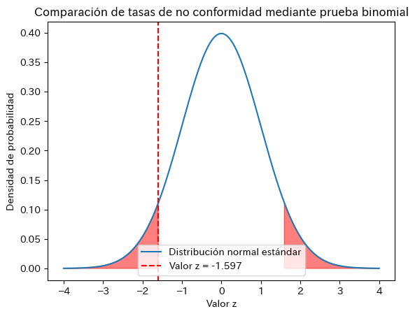

```python
import numpy as np
import matplotlib.pyplot as plt
from scipy.stats import norm

# Tamaño de muestra
n_A = 1000
n_B = 1000

# Número de defectuosos
fail_A = 15
fail_B = 25

# Tasa de defectos
p_A = fail_A / n_A
p_B = fail_B / n_B

# Tasa de defecctos total
p_pooled = (fail_A + fail_B) / (n_A + n_B)

# Error estándar
se = np.sqrt(p_pooled * (1 - p_pooled) * (1 / n_A + 1 / n_B))

# Valor Z
z = (p_A - p_B) / se

# Valor p
p_value = 2 * (1 - norm.cdf(abs(z)))


print(f"Valor z: {z:.3f}")
print(f":Valor p {p_value:.3f}")


alpha = 0.05

# Cáluculo del área de rechazo
z_critical = stats.norm.ppf(1-alpha/2)

if -z > z_critical:
    print( "Rechazo la hipótesis nula. La nueva tasa de defectos es diferente e la tasa de defectos anterior.")
else:
    print( "No rechazo la hipótesis nula. No hay diferencia entre la nueva tasa de defectos y la tasa de defectos anterior.")


# Creación de gráfico
x = np.linspace(-4, 4, 1000)
y = norm.pdf(x, 0, 1)

plt.plot(x, y, label="Distribución normal estándar")
plt.axvline(z, color='r', linestyle='--', label=f"Valor z = {z:.3f}")
plt.fill_between(x, 0, y, where=(x < -abs(z)) | (x > abs(z)), color='red', alpha=0.5)

plt.title('Comparación de tasas de no conformidad mediante prueba binomial')
plt.xlabel('Valor z')
plt.ylabel('Densidad de probabilidad')
plt.legend()
plt.show()
```

## 11.7-3

$ H_0 : \lambda = \lambda_0 \qquad (\lambda_0 = 2.0) $

$ H_1 : \lambda < \lambda_0 $

$ \alpha = 0.05 $

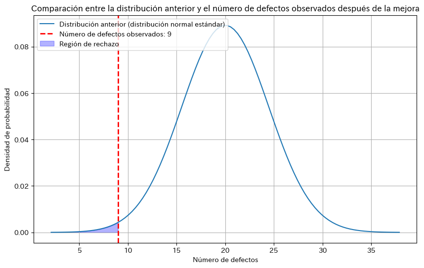

```
Valor p: 0.0070
valor z: -2.4597
```

```python
import numpy as np
import matplotlib.pyplot as plt
from scipy.stats import norm

# 従来の平均不適合数（λ）
lambda_old = 2  # 1平方メートルあたりの平均不適合数
area_old = 10  # 検査面積（平方メートル）

# 改善後の不適合数
area_new = 10  # 検査面積（平方メートル）
observed_defects = 9  # 観測された不適合数

# 母平均μと母標準偏差σ
mu = lambda_old * area_old
sigma = np.sqrt(lambda_old * area_old)

# z値の計算
z = (observed_defects - mu) / sigma

# p値の計算
p_value = norm.cdf(z)

# グラフの描画
x = np.linspace(mu - 4*sigma, mu + 4*sigma, 100)
y = norm.pdf(x, mu, sigma)

plt.figure(figsize=(10, 6))
plt.plot(x, y, label='Distribución anterior (distribución normal estándar)')
plt.axvline(observed_defects, color='red', linestyle='dashed', linewidth=2, label=f'Número de defectos observados: {observed_defects}')
plt.fill_between(x, 0, y, where=(x <= observed_defects), color='blue', alpha=0.3, label='Región de rechazo')

# グラフの設定
plt.xlabel('Número de defectos')
plt.ylabel('Densidad de probabilidad')
plt.title('Comparación entre la distribución anterior y el número de defectos observados después de la mejora')
plt.legend(loc='upper left')
plt.grid(True)
plt.show()

# p値の表示
print(f'Valor p: {p_value:.4f}')
print(f'valor z: {z:.4f}')
```

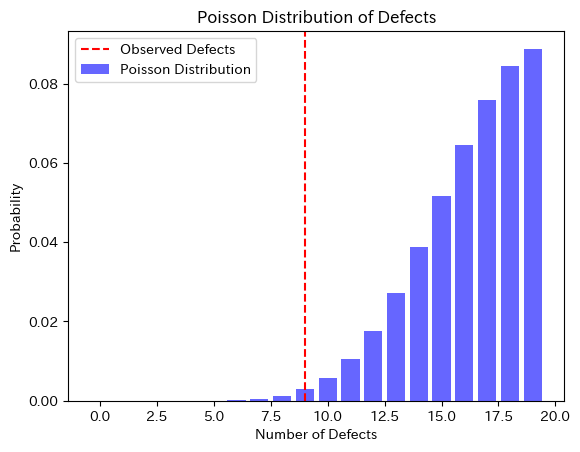

```
Número esperado de defectos en general anteriormente: 20
Número esperado de defectos después de la mejora: 20
Número de defectos observados: 9
Valor p de la prueba de Poisson: 0.0049954123083075785
El número de defectos observados ha disminuido estadísticamente en comparación con el anterior.
```

```python
import numpy as np
import matplotlib.pyplot as plt
from scipy.stats import poisson, chisquare

# Parámetros definidos
lambda_old = 2  # Tasa promedio de defectos por metro cuadrado
area_old = 10  #  Área de inspección (㎡)
area_new = 10  # Área de inspección después de la mejora (㎡)
observed_defects = 9  # Número de defectos observados después de la mejora

# Número promedio de defectos en general anteriormente
lambda_total = lambda_old * area_old

# Número esperado de defectos después de la mejora
lambda_new = lambda_old * area_new

# Prueba de Poisson para el número de defectos observados
p_value = poisson.cdf(observed_defects, lambda_new)

# Creación de gráficos
x = np.arange(0, 20, 1)
y = poisson.pmf(x, lambda_new)

plt.bar(x, y, alpha=0.6, color='b', label='Poisson Distribution')
plt.axvline(x=observed_defects, color='r', linestyle='--', label='Observed Defects')
plt.title('Poisson Distribution of Defects')
plt.xlabel('Number of Defects')
plt.ylabel('Probability')
plt.legend()
plt.show()

# 結果の表示
print(f"Número esperado de defectos en general anteriormente: {lambda_total}")
print(f"Número esperado de defectos después de la mejora: {lambda_new}")
print(f"Número de defectos observados: {observed_defects}")
print(f"Valor p de la prueba de Poisson: {p_value}")

if p_value < 0.05:
    print("El número de defectos observados ha disminuido estadísticamente en comparación con el anterior.")
else:
    print("No se puede decir que el número de defectos observados haya disminuido significativamente desde un punto de vista estadístico.")
```

## 11.7-4

$ H_0 : \lambda_C = \lambda_D $

$ H_1 : \lambda_C \neq \lambda_D $

$ \alpha = 0.05 $

```
z-statistic: 0.8944271909999157, p-value: 0.37109336952269745
```

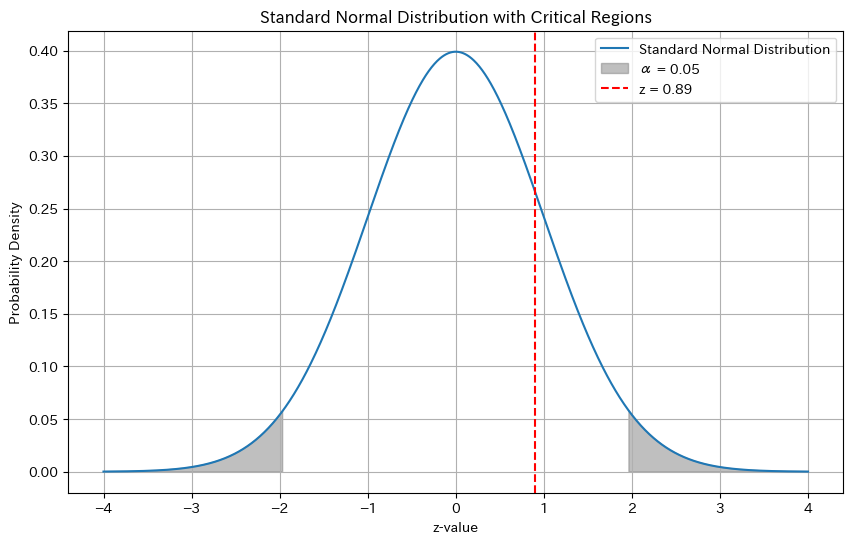

```python
import numpy as np
import scipy.stats as stats
import matplotlib.pyplot as plt

# データ設定
accidents_C = 8  # C工場の事故件数
accidents_D = 12  # D工場の事故件数
months = 10  # 観察期間（10ヶ月）

# 平均事故率の計算
lambda_C = accidents_C / months
lambda_D = accidents_D / months

# ポアソン分布に基づく標準誤差の計算
se_C = np.sqrt(lambda_C / months)
se_D = np.sqrt(lambda_D / months)

# 正規分布への近似を使用した差の標準誤差
se_diff = np.sqrt(se_C**2 + se_D**2)

# 差の計算
diff = lambda_D - lambda_C

# z値の計算
z = diff / se_diff

# p値の計算
p_value = 2 * (1 - stats.norm.cdf(np.abs(z)))

# 結果の表示
print(f'z-statistic: {z}, p-value: {p_value}')

# 有意水準
alpha = 0.05

# グラフの描画
x = np.linspace(-4, 4, 1000)
y = stats.norm.pdf(x, 0, 1)

plt.figure(figsize=(10, 6))
plt.plot(x, y, label='Standard Normal Distribution')
plt.fill_between(x, y, where=(x <= -stats.norm.ppf(1 - alpha/2)) | (x >= stats.norm.ppf(1 - alpha/2)), color='gray', alpha=0.5, label=f'α = {alpha}')
plt.axvline(z, color='red', linestyle='--', label=f'z = {z:.2f}')
plt.title('Standard Normal Distribution with Critical Regions')
plt.xlabel('z-value')
plt.ylabel('Probability Density')
plt.legend()
plt.grid(True)
plt.show()
```

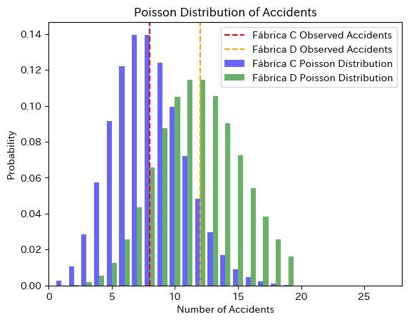

```
Tasa de accidentes mensual en la fábrica C: 0.8
Tasa de accidentes mensual en la fábrica D: 1.2
Número de accidentes observados en la fábrica C: 8
Número de accidentes observados en la fábrica D: 12
Valor p de la prueba de chi-cuadrado: 1.0
No hay una diferencia estadísticamente significativa en el número de accidentes entre la fábrica C y la fábrica D.
```

```python
import numpy as np
import matplotlib.pyplot as plt
from scipy.stats import poisson, chi2_contingency

# Parámetros definidos
accidents_C = 8  # Número de accidentes en la fábrica C
accidents_D = 12  # Número de accidentes en la fábrica D
months = 10  # Periodo de observación (10 meses)

# Tasa de accidentes mensual
rate_C = accidents_C / months
rate_D = accidents_D / months

# Calcular el valor esperado
expected_accidents_C = rate_C * months
expected_accidents_D = rate_D * months

# Lista de valores observados y esperados
observed = np.array([accidents_C, accidents_D])
expected = np.array([expected_accidents_C, expected_accidents_D])

# Prueba de chi-cuadrado
chi2, p_value, dof, ex = chi2_contingency([observed, expected])

# Creación de gráficos
x = np.arange(0, 20, 1)
y_C = poisson.pmf(x, expected_accidents_C)
y_D = poisson.pmf(x, expected_accidents_D)

plt.bar(x - 0.2, y_C, width=0.4, alpha=0.6, color='b', label='Fábrica C Poisson Distribution')
plt.bar(x + 0.2, y_D, width=0.4, alpha=0.6, color='g', label='Fábrica D Poisson Distribution')
plt.axvline(x=accidents_C, color='r', linestyle='--', label='Fábrica C Observed Accidents')
plt.axvline(x=accidents_D, color='orange', linestyle='--', label='Fábrica D Observed Accidents')
plt.xlim(0,28)
plt.title('Poisson Distribution of Accidents')
plt.xlabel('Number of Accidents')
plt.ylabel('Probability')
plt.legend()
plt.show()

# 結果の表示
print(f"Tasa de accidentes mensual en la fábrica C: {rate_C}")
print(f"Tasa de accidentes mensual en la fábrica D: {rate_D}")
print(f"Número de accidentes observados en la fábrica C: {accidents_C}")
print(f"Número de accidentes observados en la fábrica D: {accidents_D}")
print(f"Valor p de la prueba de chi-cuadrado: {p_value}")

if p_value < 0.05:
    print("Hay una diferencia estadísticamente significativa en el número de accidentes entre la fábrica C y la fábrica D.")
else:
    print("No hay una diferencia estadísticamente significativa en el número de accidentes entre la fábrica C y la fábrica D.")
```

## 11.8

```python
import numpy as np
from scipy.stats import chi2_contingency

# Datos de la tabla de contingencia
observed = np.array([[160, 40],
                     [170, 30],
                     [150, 50]])


# Cálculo de la frecuencia esperada
row_totals = observed.sum(axis=1)
col_totals = observed.sum(axis=0)
total = observed.sum()

expected = np.outer(row_totals, col_totals) / total

# Estadístico chi-cuadrado、Valor p、Grados de libertad、Cálculo de la frecuencia esperada
chi2_stat, p_val, dof, expected = chi2_contingency(observed)

# Mostrar resultados
print("Tabla de contingencia:")
print(observed)
print("\nFrecuencias esperadas:")
print(expected)
print(f"\nEstadístico Chi-cuadrado: {chi2_stat:.2f}")
print(f"Valor p: {p_val:.4f}")
print(f"Grados de libertad: {dof}")

#  Juicio estadístico usando el valor p
alpha = 0.05
if p_val < alpha:
    print("\nHay una diferencia estadísticamente significativa.")
else:
    print("\nNo hay una diferencia estadísticamente significativa")
```

```
Tabla de contingencia:
[[160  40]
 [170  30]
 [150  50]]

Frecuencias esperadas:
[[160.  40.]
 [160.  40.]
 [160.  40.]]

Estadístico Chi-cuadrado: 6.25
Valor p: 0.0439
Grados de libertad: 2

Hay una diferencia estadísticamente significativa.
```

```python
df = pd.DataFrame(observed, index=['Fabrica A','Fabrica B','Fabrica C'], columns=['Prduct confirme','no confirme'])
df.loc["Total"] = df.sum()
df['Total'] = df.sum(axis=1)
df.to_excel('Data2/11_1.xlsx')
```

```python
df = pd.DataFrame(expected, index=['Fabrica A','Fabrica B','Fabrica C'], columns=['Prduct confirme','no confirme'])
df.loc["Total"] = df.sum()
df['Total'] = df.sum(axis=1)
df.to_excel('Data2/11_2.xlsx')
```

```python
import numpy as np
from scipy.stats import norm

prob_values = []

# 標準正規分布表の作成
for i in np.arange(0, 3.1, 0.01):
      prob_values.append(1- norm.cdf(i))

df = pd.DataFrame(np.array(prob_values).reshape(31,10))
df.index = np.arange(0.0, 3.1, 0.1)
df.to_excel('Data2/TablaDistribucionNormal.xlsx')
df
```

|  | 0 | 1 | 2 | 3 | 4 | 5 | 6 | 7 | 8 | 9 |
| --- | --- | --- | --- | --- | --- | --- | --- | --- | --- | --- |
| 0.0 | 0.500000 | 0.496011 | 0.492022 | 0.488034 | 0.484047 | 0.480061 | 0.476078 | 0.472097 | 0.468119 | 0.464144 |
| 0.1 | 0.460172 | 0.456205 | 0.452242 | 0.448283 | 0.444330 | 0.440382 | 0.436441 | 0.432505 | 0.428576 | 0.424655 |
| 0.2 | 0.420740 | 0.416834 | 0.412936 | 0.409046 | 0.405165 | 0.401294 | 0.397432 | 0.393580 | 0.389739 | 0.385908 |
| 0.3 | 0.382089 | 0.378280 | 0.374484 | 0.370700 | 0.366928 | 0.363169 | 0.359424 | 0.355691 | 0.351973 | 0.348268 |
| 0.4 | 0.344578 | 0.340903 | 0.337243 | 0.333598 | 0.329969 | 0.326355 | 0.322758 | 0.319178 | 0.315614 | 0.312067 |
| 0.5 | 0.308538 | 0.305026 | 0.301532 | 0.298056 | 0.294599 | 0.291160 | 0.287740 | 0.284339 | 0.280957 | 0.277595 |
| 0.6 | 0.274253 | 0.270931 | 0.267629 | 0.264347 | 0.261086 | 0.257846 | 0.254627 | 0.251429 | 0.248252 | 0.245097 |
| 0.7 | 0.241964 | 0.238852 | 0.235762 | 0.232695 | 0.229650 | 0.226627 | 0.223627 | 0.220650 | 0.217695 | 0.214764 |
| 0.8 | 0.211855 | 0.208970 | 0.206108 | 0.203269 | 0.200454 | 0.197663 | 0.194895 | 0.192150 | 0.189430 | 0.186733 |
| 0.9 | 0.184060 | 0.181411 | 0.178786 | 0.176186 | 0.173609 | 0.171056 | 0.168528 | 0.166023 | 0.163543 | 0.161087 |
| 1.0 | 0.158655 | 0.156248 | 0.153864 | 0.151505 | 0.149170 | 0.146859 | 0.144572 | 0.142310 | 0.140071 | 0.137857 |
| 1.1 | 0.135666 | 0.133500 | 0.131357 | 0.129238 | 0.127143 | 0.125072 | 0.123024 | 0.121000 | 0.119000 | 0.117023 |
| 1.2 | 0.115070 | 0.113139 | 0.111232 | 0.109349 | 0.107488 | 0.105650 | 0.103835 | 0.102042 | 0.100273 | 0.098525 |
| 1.3 | 0.096800 | 0.095098 | 0.093418 | 0.091759 | 0.090123 | 0.088508 | 0.086915 | 0.085343 | 0.083793 | 0.082264 |
| 1.4 | 0.080757 | 0.079270 | 0.077804 | 0.076359 | 0.074934 | 0.073529 | 0.072145 | 0.070781 | 0.069437 | 0.068112 |
| 1.5 | 0.066807 | 0.065522 | 0.064255 | 0.063008 | 0.061780 | 0.060571 | 0.059380 | 0.058208 | 0.057053 | 0.055917 |
| 1.6 | 0.054799 | 0.053699 | 0.052616 | 0.051551 | 0.050503 | 0.049471 | 0.048457 | 0.047460 | 0.046479 | 0.045514 |
| 1.7 | 0.044565 | 0.043633 | 0.042716 | 0.041815 | 0.040930 | 0.040059 | 0.039204 | 0.038364 | 0.037538 | 0.036727 |
| 1.8 | 0.035930 | 0.035148 | 0.034380 | 0.033625 | 0.032884 | 0.032157 | 0.031443 | 0.030742 | 0.030054 | 0.029379 |
| 1.9 | 0.028717 | 0.028067 | 0.027429 | 0.026803 | 0.026190 | 0.025588 | 0.024998 | 0.024419 | 0.023852 | 0.023295 |
| 2.0 | 0.022750 | 0.022216 | 0.021692 | 0.021178 | 0.020675 | 0.020182 | 0.019699 | 0.019226 | 0.018763 | 0.018309 |
| 2.1 | 0.017864 | 0.017429 | 0.017003 | 0.016586 | 0.016177 | 0.015778 | 0.015386 | 0.015003 | 0.014629 | 0.014262 |
| 2.2 | 0.013903 | 0.013553 | 0.013209 | 0.012874 | 0.012545 | 0.012224 | 0.011911 | 0.011604 | 0.011304 | 0.011011 |
| 2.3 | 0.010724 | 0.010444 | 0.010170 | 0.009903 | 0.009642 | 0.009387 | 0.009137 | 0.008894 | 0.008656 | 0.008424 |
| 2.4 | 0.008198 | 0.007976 | 0.007760 | 0.007549 | 0.007344 | 0.007143 | 0.006947 | 0.006756 | 0.006569 | 0.006387 |
| 2.5 | 0.006210 | 0.006037 | 0.005868 | 0.005703 | 0.005543 | 0.005386 | 0.005234 | 0.005085 | 0.004940 | 0.004799 |
| 2.6 | 0.004661 | 0.004527 | 0.004396 | 0.004269 | 0.004145 | 0.004025 | 0.003907 | 0.003793 | 0.003681 | 0.003573 |
| 2.7 | 0.003467 | 0.003364 | 0.003264 | 0.003167 | 0.003072 | 0.002980 | 0.002890 | 0.002803 | 0.002718 | 0.002635 |
| 2.8 | 0.002555 | 0.002477 | 0.002401 | 0.002327 | 0.002256 | 0.002186 | 0.002118 | 0.002052 | 0.001988 | 0.001926 |
| 2.9 | 0.001866 | 0.001807 | 0.001750 | 0.001695 | 0.001641 | 0.001589 | 0.001538 | 0.001489 | 0.001441 | 0.001395 |
| 3.0 | 0.001350 | 0.001306 | 0.001264 | 0.001223 | 0.001183 | 0.001144 | 0.001107 | 0.001070 | 0.001035 | 0.001001 |

```python
fp = []

for p in np.arange(0,0.01,0.001):
  fp.append(-norm.ppf(p))


for p in np.arange(0,0.5,0.01):
  fp.append(-norm.ppf(p))

len(fp)
df = pd.DataFrame(np.array(fp).reshape(6,10))
ind = ['0.00','0.0','0.1','0.2','0.3','0.4']
df.index = ind
df.to_excel('Data2/TablaDistribucionNormal2.xlsx')
df
```

|  | 0 | 1 | 2 | 3 | 4 | 5 | 6 | 7 | 8 | 9 |
| --- | --- | --- | --- | --- | --- | --- | --- | --- | --- | --- |
| 0.00 | inf | 3.090232 | 2.878162 | 2.747781 | 2.652070 | 2.575829 | 2.512144 | 2.457263 | 2.408916 | 2.365618 |
| 0.0 | inf | 2.326348 | 2.053749 | 1.880794 | 1.750686 | 1.644854 | 1.554774 | 1.475791 | 1.405072 | 1.340755 |
| 0.1 | 1.281552 | 1.226528 | 1.174987 | 1.126391 | 1.080319 | 1.036433 | 0.994458 | 0.954165 | 0.915365 | 0.877896 |
| 0.2 | 0.841621 | 0.806421 | 0.772193 | 0.738847 | 0.706303 | 0.674490 | 0.643345 | 0.612813 | 0.582842 | 0.553385 |
| 0.3 | 0.524401 | 0.495850 | 0.467699 | 0.439913 | 0.412463 | 0.385320 | 0.358459 | 0.331853 | 0.305481 | 0.279319 |
| 0.4 | 0.253347 | 0.227545 | 0.201893 | 0.176374 | 0.150969 | 0.125661 | 0.100434 | 0.075270 | 0.050154 | 0.025069 |

```python
import numpy as np
import pandas as pd
import scipy.stats as stats

def create_f_table(phi1_range, phi2_range, alpha=0.025):
    # Initialize an empty DataFrame to store the F critical values
    f_table = pd.DataFrame(index=phi2_range, columns=phi1_range)

    # Fill the DataFrame with the critical values
    for phi1 in phi1_range:
        for phi2 in phi2_range:
          if phi1 == inf:
            f_critical = stats.f.isf(alpha, phi1, phi2)
          else:
            f_critical = stats.f.ppf(1 - alpha, phi1, phi2)
          f_table.loc[phi2, phi1] = f_critical

    return f_table

inf = 1e10
phi1_range10 = np.array([12,15,20,24,30,40,60,120,inf])
phi2_range10 = np.array([12,15,20,24,30,40,60,120,inf])

# Define the ranges for phi1 and phi2
phi1_range = np.concatenate([np.arange(1, 11),phi1_range10])  # Change this range as needed
phi2_range = np.concatenate([np.arange(1, 11),phi2_range10])  # Change this range as needed

# Create the F table with alpha = 0.025
f_table = create_f_table(phi1_range, phi2_range, alpha=0.025)
# Display the F table


phi1_range_col = [str(int(n)) for n in phi1_range]
phi1_range_col= [s.replace('10000000000','inf') for s in phi1_range_col]
phi1_range_col

phi2_range_index = [str(int(n)) for n in phi2_range]
phi2_range_index= [s.replace('10000000000','inf') for s in phi2_range_index]
phi2_range_index

f_table.columns = phi1_range_col
f_table.index = phi2_range_index
f_table.to_excel('Data2/Tabla_F_025.xlsx')
f_table
```

|  | 1 | 2 | 3 | 4 | 5 | 6 | 7 | 8 | 9 | 10 | 12 | 15 | 20 | 24 | 30 | 40 | 60 | 120 | inf |
| --- | --- | --- | --- | --- | --- | --- | --- | --- | --- | --- | --- | --- | --- | --- | --- | --- | --- | --- | --- |
| 1 | 647.789011 | 799.5 | 864.162972 | 899.58331 | 921.847903 | 937.111083 | 948.216889 | 956.656221 | 963.284579 | 968.627444 | 976.70795 | 984.866841 | 993.102805 | 997.249245 | 1001.414408 | 1005.598097 | 1009.80011 | 1014.020239 | 1018.25827 |
| 2 | 38.506329 | 39.0 | 39.165495 | 39.248418 | 39.298228 | 39.331458 | 39.355205 | 39.373022 | 39.386883 | 39.397975 | 39.414615 | 39.431261 | 39.447911 | 39.456238 | 39.464566 | 39.472895 | 39.481226 | 39.489557 | 39.49789 |
| 3 | 17.443443 | 16.044106 | 15.439182 | 15.100979 | 14.884823 | 14.734718 | 14.624395 | 14.539887 | 14.473081 | 14.418942 | 14.336552 | 14.252711 | 14.167381 | 14.124146 | 14.080523 | 14.036509 | 13.992098 | 13.947285 | 13.902065 |
| 4 | 12.217863 | 10.649111 | 9.979199 | 9.60453 | 9.364471 | 9.197311 | 9.074141 | 8.97958 | 8.904682 | 8.843881 | 8.751159 | 8.656541 | 8.559943 | 8.510873 | 8.461274 | 8.411132 | 8.360436 | 8.30917 | 8.257322 |
| 5 | 10.006982 | 8.433621 | 7.763589 | 7.387886 | 7.146382 | 6.977702 | 6.853076 | 6.757172 | 6.681054 | 6.619154 | 6.524549 | 6.427728 | 6.328555 | 6.27804 | 6.226879 | 6.17505 | 6.122529 | 6.069293 | 6.015315 |
| 6 | 8.813101 | 7.259856 | 6.598799 | 6.227161 | 5.987565 | 5.819757 | 5.69547 | 5.599623 | 5.523407 | 5.461324 | 5.366244 | 5.268667 | 5.168401 | 5.117192 | 5.065227 | 5.012471 | 4.958891 | 4.904446 | 4.849095 |
| 7 | 8.072669 | 6.54152 | 5.889819 | 5.522594 | 5.285237 | 5.118597 | 4.994909 | 4.899341 | 4.823217 | 4.761116 | 4.66583 | 4.567787 | 4.46674 | 4.414999 | 4.362393 | 4.308876 | 4.254398 | 4.198904 | 4.142332 |
| 8 | 7.570882 | 6.059467 | 5.415962 | 5.052632 | 4.817276 | 4.651696 | 4.528562 | 4.43326 | 4.357233 | 4.295127 | 4.199667 | 4.101213 | 3.999453 | 3.94722 | 3.894016 | 3.83978 | 3.784446 | 3.72794 | 3.670178 |
| 9 | 7.209283 | 5.714705 | 5.078119 | 4.718078 | 4.484411 | 4.319722 | 4.197047 | 4.101956 | 4.025994 | 3.963865 | 3.86822 | 3.769357 | 3.666906 | 3.614196 | 3.56041 | 3.505474 | 3.449302 | 3.391799 | 3.332852 |
| 10 | 6.936728 | 5.456396 | 4.825621 | 4.468342 | 4.236086 | 4.072131 | 3.949824 | 3.854891 | 3.778963 | 3.716792 | 3.620945 | 3.521673 | 3.418544 | 3.365369 | 3.311017 | 3.255396 | 3.198402 | 3.139914 | 3.079792 |
| 12 | 6.553769 | 5.095867 | 4.474185 | 4.121209 | 3.891134 | 3.728292 | 3.606515 | 3.511777 | 3.435846 | 3.373553 | 3.277277 | 3.177201 | 3.072773 | 3.018711 | 2.963278 | 2.906346 | 2.847768 | 2.787365 | 2.724927 |
| 15 | 6.199501 | 4.765048 | 4.152804 | 3.804271 | 3.576415 | 3.414665 | 3.29336 | 3.198738 | 3.122712 | 3.060197 | 2.963282 | 2.862093 | 2.755902 | 2.70064 | 2.643735 | 2.585005 | 2.524226 | 2.461122 | 2.395348 |
| 20 | 5.871494 | 4.461255 | 3.858699 | 3.514695 | 3.289056 | 3.12834 | 3.007416 | 2.912797 | 2.836546 | 2.773671 | 2.675831 | 2.573096 | 2.464484 | 2.407562 | 2.348602 | 2.287322 | 2.223359 | 2.156242 | 2.085337 |
| 24 | 5.716639 | 4.318726 | 3.72108 | 3.379359 | 3.154816 | 2.994586 | 2.873808 | 2.779135 | 2.702711 | 2.63959 | 2.541148 | 2.437429 | 2.327271 | 2.269277 | 2.208976 | 2.146 | 2.079873 | 2.009946 | 1.935304 |
| 30 | 5.567535 | 4.182061 | 3.589359 | 3.249925 | 3.026466 | 2.866696 | 2.746027 | 2.651256 | 2.57461 | 2.511191 | 2.412034 | 2.307154 | 2.19516 | 2.135879 | 2.073944 | 2.008872 | 1.940008 | 1.866418 | 1.786696 |
| 40 | 5.423937 | 4.050992 | 3.46326 | 3.126114 | 2.903722 | 2.744382 | 2.623781 | 2.528863 | 2.451939 | 2.388161 | 2.288157 | 2.181903 | 2.067714 | 2.006868 | 1.942916 | 1.875197 | 1.80277 | 1.724205 | 1.637127 |
| 60 | 5.285611 | 3.925265 | 3.34252 | 3.007659 | 2.786315 | 2.62737 | 2.506792 | 2.411672 | 2.334406 | 2.270198 | 2.169192 | 2.061308 | 1.94447 | 1.881696 | 1.815202 | 1.744046 | 1.666791 | 1.581034 | 1.482149 |
| 120 | 5.152331 | 3.804638 | 3.22689 | 2.894308 | 2.673988 | 2.515401 | 2.394794 | 2.29941 | 2.22173 | 2.157011 | 2.05482 | 1.944992 | 1.82492 | 1.759725 | 1.689944 | 1.614147 | 1.529942 | 1.432677 | 1.310435 |
| inf | 5.023887 | 3.688879 | 3.116135 | 2.785822 | 2.5665 | 2.408229 | 2.287538 | 2.191818 | 2.113641 | 2.048318 | 1.944722 | 1.83256 | 1.70848 | 1.64017 | 1.565975 | 1.483543 | 1.388295 | 1.268428 | 1.000039 |

```python
inf = 1e10
phi1_range10 = np.array([12,15,20,24,30,40,60,120,inf])
phi2_range10 = np.array([12,15,20,24,30,40,60,120,inf])

# Define the ranges for phi1 and phi2
phi1_range = np.concatenate([np.arange(1, 11),phi1_range10])  # Change this range as needed
phi2_range = np.concatenate([np.arange(1, 11),phi2_range10])  # Change this range as needed

# Create the F table with alpha = 1
f_table = create_f_table(phi1_range, phi2_range, alpha=0.01)
# Display the F table


phi1_range_col = [str(int(n)) for n in phi1_range]
phi1_range_col= [s.replace('10000000000','inf') for s in phi1_range_col]
phi1_range_col

phi2_range_index = [str(int(n)) for n in phi2_range]
phi2_range_index= [s.replace('10000000000','inf') for s in phi2_range_index]
phi2_range_index

f_table.columns = phi1_range_col
f_table.index = phi2_range_index
f_table.to_excel('Data2/Tabla_F_01.xlsx')
f_table
```

|  | 1 | 2 | 3 | 4 | 5 | 6 | 7 | 8 | 9 | 10 | 12 | 15 | 20 | 24 | 30 | 40 | 60 | 120 | inf |
| --- | --- | --- | --- | --- | --- | --- | --- | --- | --- | --- | --- | --- | --- | --- | --- | --- | --- | --- | --- |
| 1 | 4052.180695 | 4999.5 | 5403.352014 | 5624.58333 | 5763.649554 | 5858.986107 | 5928.355732 | 5981.070308 | 6022.473245 | 6055.846707 | 6106.320708 | 6157.284615 | 6208.730222 | 6234.630894 | 6260.648579 | 6286.782054 | 6313.030053 | 6339.391275 | 6365.864385 |
| 2 | 98.502513 | 99.0 | 99.166201 | 99.249372 | 99.299296 | 99.332589 | 99.356374 | 99.374215 | 99.388093 | 99.399196 | 99.415852 | 99.432511 | 99.449171 | 99.457502 | 99.465833 | 99.474165 | 99.482497 | 99.490829 | 99.499162 |
| 3 | 34.116222 | 30.81652 | 29.456695 | 28.709898 | 28.237081 | 27.910657 | 27.671696 | 27.489177 | 27.345206 | 27.228734 | 27.051819 | 26.872195 | 26.689791 | 26.597523 | 26.504534 | 26.410813 | 26.316351 | 26.221139 | 26.125167 |
| 4 | 21.19769 | 18.0 | 16.694369 | 15.977025 | 15.521858 | 15.206865 | 14.975758 | 14.798889 | 14.659134 | 14.545901 | 14.373587 | 14.198202 | 14.019609 | 13.929064 | 13.83766 | 13.745379 | 13.652198 | 13.558096 | 13.463051 |
| 5 | 16.258177 | 13.273934 | 12.059954 | 11.391928 | 10.967021 | 10.672255 | 10.455511 | 10.289311 | 10.157762 | 10.051017 | 9.888275 | 9.722219 | 9.552646 | 9.466471 | 9.379329 | 9.291189 | 9.202015 | 9.111771 | 9.020417 |
| 6 | 13.745023 | 10.924767 | 9.779538 | 9.148301 | 8.745895 | 8.466125 | 8.259995 | 8.101651 | 7.976121 | 7.874119 | 7.718333 | 7.558994 | 7.395832 | 7.312721 | 7.228533 | 7.143222 | 7.056737 | 6.969023 | 6.880021 |
| 7 | 12.246383 | 9.546578 | 8.451285 | 7.846645 | 7.460435 | 7.191405 | 6.992833 | 6.840049 | 6.718752 | 6.620063 | 6.469091 | 6.314331 | 6.155438 | 6.074319 | 5.99201 | 5.908449 | 5.823566 | 5.737286 | 5.649525 |
| 8 | 11.258624 | 8.649111 | 7.590992 | 7.006077 | 6.631825 | 6.370681 | 6.177624 | 6.02887 | 5.910619 | 5.814294 | 5.666719 | 5.515125 | 5.359095 | 5.279264 | 5.19813 | 5.11561 | 5.031618 | 4.946052 | 4.858799 |
| 9 | 10.561431 | 8.021517 | 6.991917 | 6.422085 | 6.056941 | 5.80177 | 5.612865 | 5.467123 | 5.351129 | 5.256542 | 5.111431 | 4.962078 | 4.807995 | 4.728998 | 4.648582 | 4.566649 | 4.483087 | 4.397769 | 4.31055 |
| 10 | 10.044289 | 7.559432 | 6.552313 | 5.994339 | 5.636326 | 5.385811 | 5.200121 | 5.056693 | 4.942421 | 4.849147 | 4.70587 | 4.55814 | 4.405395 | 4.326929 | 4.246933 | 4.165287 | 4.081855 | 3.996481 | 3.90898 |
| 12 | 9.330212 | 6.926608 | 5.952545 | 5.411951 | 5.064343 | 4.820574 | 4.639502 | 4.499365 | 4.38751 | 4.296054 | 4.155258 | 4.009619 | 3.858433 | 3.780485 | 3.700789 | 3.619181 | 3.535473 | 3.44944 | 3.360809 |
| 15 | 8.683117 | 6.358873 | 5.416965 | 4.89321 | 4.555614 | 4.318273 | 4.141546 | 4.004453 | 3.894788 | 3.80494 | 3.66624 | 3.522194 | 3.371892 | 3.294029 | 3.21411 | 3.131906 | 3.047135 | 2.959453 | 2.868426 |
| 20 | 8.095958 | 5.848932 | 4.938193 | 4.43069 | 4.102685 | 3.871427 | 3.69874 | 3.564412 | 3.456676 | 3.368186 | 3.23112 | 3.088041 | 2.937735 | 2.859363 | 2.778485 | 2.694749 | 2.607708 | 2.516783 | 2.421191 |
| 24 | 7.822871 | 5.613591 | 4.718051 | 4.218445 | 3.89507 | 3.666717 | 3.495928 | 3.362867 | 3.255985 | 3.168069 | 3.031615 | 2.888732 | 2.737997 | 2.659072 | 2.577329 | 2.492321 | 2.403461 | 2.309955 | 2.210685 |
| 30 | 7.562476 | 5.390346 | 4.50974 | 4.017877 | 3.699019 | 3.473477 | 3.304499 | 3.172624 | 3.066516 | 2.979094 | 2.843095 | 2.70018 | 2.548659 | 2.468921 | 2.385967 | 2.299211 | 2.207854 | 2.110762 | 2.006225 |
| 40 | 7.3141 | 5.178508 | 4.312569 | 3.828294 | 3.51384 | 3.291012 | 3.123757 | 2.992981 | 2.88756 | 2.800545 | 2.664827 | 2.521616 | 2.368876 | 2.287998 | 2.203382 | 2.114232 | 2.019411 | 1.917191 | 1.804707 |
| 60 | 7.077106 | 4.977432 | 4.125892 | 3.649047 | 3.338884 | 3.118674 | 2.953049 | 2.82328 | 2.718454 | 2.631751 | 2.496116 | 2.352297 | 2.197806 | 2.115364 | 2.028479 | 1.936018 | 1.836259 | 1.72632 | 1.600647 |
| 120 | 6.850893 | 4.78651 | 3.9491 | 3.479531 | 3.173545 | 2.955854 | 2.791764 | 2.662906 | 2.558574 | 2.472077 | 2.3363 | 2.191504 | 2.034588 | 1.950018 | 1.860005 | 1.762849 | 1.655693 | 1.532992 | 1.380528 |
| inf | 6.634898 | 4.60517 | 3.781622 | 3.319176 | 3.017254 | 2.801982 | 2.63933 | 2.511279 | 2.407333 | 2.320925 | 2.184747 | 2.038528 | 1.878312 | 1.790826 | 1.696406 | 1.592268 | 1.47299 | 1.324585 | 1.000047 |

```python
inf = 1e10
phi1_range10 = np.array([12,15,20,24,30,40,60,120,inf])
phi2_range10 = np.array([12,15,20,24,30,40,60,120,inf])

# Define the ranges for phi1 and phi2
phi1_range = np.concatenate([np.arange(1, 11),phi1_range10])  # Change this range as needed
phi2_range = np.concatenate([np.arange(1, 11),phi2_range10])  # Change this range as needed

# Create the F table with alpha = 1
f_table = create_f_table(phi1_range, phi2_range, alpha=0.05)
# Display the F table


phi1_range_col = [str(int(n)) for n in phi1_range]
phi1_range_col= [s.replace('10000000000','inf') for s in phi1_range_col]
phi1_range_col

phi2_range_index = [str(int(n)) for n in phi2_range]
phi2_range_index= [s.replace('10000000000','inf') for s in phi2_range_index]
phi2_range_index

f_table.columns = phi1_range_col
f_table.index = phi2_range_index
f_table.to_excel('Data2/Tabla_F_05.xlsx')
f_table
```

|  | 1 | 2 | 3 | 4 | 5 | 6 | 7 | 8 | 9 | 10 | 12 | 15 | 20 | 24 | 30 | 40 | 60 | 120 | inf |
| --- | --- | --- | --- | --- | --- | --- | --- | --- | --- | --- | --- | --- | --- | --- | --- | --- | --- | --- | --- |
| 1 | 161.447639 | 199.5 | 215.707345 | 224.583241 | 230.161878 | 233.986 | 236.7684 | 238.882695 | 240.543255 | 241.881747 | 243.906038 | 245.949926 | 248.013082 | 249.051775 | 250.095148 | 251.143153 | 252.195739 | 253.252854 | 254.314445 |
| 2 | 18.512821 | 19.0 | 19.164292 | 19.246794 | 19.29641 | 19.329534 | 19.353218 | 19.370993 | 19.384826 | 19.395897 | 19.412511 | 19.429135 | 19.445768 | 19.454089 | 19.462411 | 19.470736 | 19.479064 | 19.487394 | 19.495726 |
| 3 | 10.127964 | 9.552094 | 9.276628 | 9.117182 | 9.013455 | 8.940645 | 8.886743 | 8.845238 | 8.8123 | 8.785525 | 8.744641 | 8.70287 | 8.66019 | 8.638501 | 8.616576 | 8.594411 | 8.572004 | 8.549351 | 8.52645 |
| 4 | 7.708647 | 6.944272 | 6.591382 | 6.388233 | 6.256057 | 6.163132 | 6.094211 | 6.041044 | 5.998779 | 5.964371 | 5.911729 | 5.857805 | 5.802542 | 5.774389 | 5.745877 | 5.716998 | 5.687744 | 5.658105 | 5.628072 |
| 5 | 6.607891 | 5.786135 | 5.409451 | 5.192168 | 5.050329 | 4.950288 | 4.875872 | 4.81832 | 4.772466 | 4.735063 | 4.677704 | 4.618759 | 4.558131 | 4.527153 | 4.495712 | 4.463793 | 4.43138 | 4.398454 | 4.364997 |
| 6 | 5.987378 | 5.143253 | 4.757063 | 4.533677 | 4.387374 | 4.283866 | 4.206658 | 4.146804 | 4.099016 | 4.059963 | 3.999935 | 3.938058 | 3.874189 | 3.841457 | 3.808164 | 3.774286 | 3.739797 | 3.704667 | 3.668866 |
| 7 | 5.591448 | 4.737414 | 4.346831 | 4.120312 | 3.971523 | 3.865969 | 3.787044 | 3.725725 | 3.676675 | 3.636523 | 3.574676 | 3.51074 | 3.444525 | 3.410494 | 3.375808 | 3.34043 | 3.304323 | 3.267445 | 3.229751 |
| 8 | 5.317655 | 4.45897 | 4.066181 | 3.837853 | 3.687499 | 3.58058 | 3.500464 | 3.438101 | 3.38813 | 3.347163 | 3.283939 | 3.218406 | 3.150324 | 3.11524 | 3.079406 | 3.042778 | 3.005303 | 2.966923 | 2.927575 |
| 9 | 5.117355 | 4.256495 | 3.862548 | 3.633089 | 3.481659 | 3.373754 | 3.292746 | 3.229583 | 3.178893 | 3.13728 | 3.072947 | 3.006102 | 2.936455 | 2.900474 | 2.863652 | 2.825933 | 2.787249 | 2.747525 | 2.706675 |
| 10 | 4.964603 | 4.102821 | 3.708265 | 3.47805 | 3.325835 | 3.217175 | 3.135465 | 3.071658 | 3.020383 | 2.978237 | 2.912977 | 2.845017 | 2.774016 | 2.737248 | 2.699551 | 2.660855 | 2.621077 | 2.580122 | 2.537878 |
| 12 | 4.747225 | 3.885294 | 3.490295 | 3.259167 | 3.105875 | 2.99612 | 2.913358 | 2.848565 | 2.796375 | 2.753387 | 2.686637 | 2.616851 | 2.543588 | 2.505482 | 2.466279 | 2.42588 | 2.384166 | 2.340995 | 2.296198 |
| 15 | 4.543077 | 3.68232 | 3.287382 | 3.055568 | 2.901295 | 2.790465 | 2.706627 | 2.640797 | 2.587626 | 2.543719 | 2.475313 | 2.403447 | 2.327535 | 2.287826 | 2.246789 | 2.204276 | 2.160105 | 2.114056 | 2.065847 |
| 20 | 4.351244 | 3.492828 | 3.098391 | 2.866081 | 2.71089 | 2.598978 | 2.514011 | 2.447064 | 2.392814 | 2.347878 | 2.277581 | 2.203274 | 2.124155 | 2.082454 | 2.039086 | 1.993819 | 1.946358 | 1.896318 | 1.84318 |
| 24 | 4.259677 | 3.402826 | 3.008787 | 2.776289 | 2.620654 | 2.508189 | 2.422629 | 2.355081 | 2.300244 | 2.254739 | 2.18338 | 2.107673 | 2.026664 | 1.98376 | 1.938957 | 1.891955 | 1.84236 | 1.789642 | 1.733049 |
| 30 | 4.170877 | 3.31583 | 2.922277 | 2.689628 | 2.533555 | 2.420523 | 2.334344 | 2.266163 | 2.210697 | 2.16458 | 2.092063 | 2.014804 | 1.931653 | 1.88736 | 1.840872 | 1.79179 | 1.739574 | 1.683452 | 1.622265 |
| 40 | 4.084746 | 3.231727 | 2.838745 | 2.605975 | 2.449466 | 2.335852 | 2.249024 | 2.18017 | 2.124029 | 2.077248 | 2.003459 | 1.924463 | 1.838859 | 1.792937 | 1.744432 | 1.692797 | 1.637252 | 1.57661 | 1.508904 |
| 60 | 4.001191 | 3.150411 | 2.758078 | 2.525215 | 2.36827 | 2.254053 | 2.166541 | 2.096968 | 2.040098 | 1.992592 | 1.917396 | 1.836437 | 1.747984 | 1.700117 | 1.649141 | 1.594273 | 1.534314 | 1.467267 | 1.389276 |
| 120 | 3.920124 | 3.071779 | 2.680168 | 2.447237 | 2.289851 | 2.175006 | 2.08677 | 2.016426 | 1.958763 | 1.910461 | 1.833695 | 1.750497 | 1.65868 | 1.608437 | 1.554343 | 1.495202 | 1.429013 | 1.351886 | 1.253858 |
| inf | 3.841459 | 2.995732 | 2.604909 | 2.371933 | 2.2141 | 2.098598 | 2.009592 | 1.938414 | 1.879886 | 1.830704 | 1.752172 | 1.666386 | 1.570522 | 1.517293 | 1.459099 | 1.393962 | 1.318032 | 1.221395 | 1.000033 |

```python
import numpy as np
import pandas as pd
import scipy.stats as stats

def create_r_table(phi_range, p_values):
    # Initialize an empty DataFrame to store the r critical values
    r_table = pd.DataFrame(index=phi_range, columns=p_values)

    # Fill the DataFrame with the critical values
    for phi in phi_range:
        for p in p_values:
            alpha = 1 - p / 2  # Convert two-tailed P value to one-tailed alpha
            t_critical = stats.t.ppf(alpha, phi)
            r_critical = t_critical / np.sqrt(phi + t_critical**2)
            r_table.loc[phi, p] = r_critical

    return r_table

# Define the ranges for phi (degrees of freedom) and P (two-tailed probability values)
phi_range = np.concatenate((np.arange(10, 20),np.arange(20,45,5),np.arange(50,110,10)))  # Change this range as needed
p_values = [0.10, 0.05, 0.02, 0.01]  # Common P values

# Create the r table
r_table = create_r_table(phi_range, p_values)

r_table.to_excel('Data2/Tabla_r.xlsx')

# Display the r table
r_table
```

|  | 0.10 | 0.05 | 0.02 | 0.01 |
| --- | --- | --- | --- | --- |
| 10 | 0.497265 | 0.575983 | 0.65807 | 0.707888 |
| 11 | 0.476156 | 0.552943 | 0.633863 | 0.683528 |
| 12 | 0.4575 | 0.532413 | 0.612047 | 0.661376 |
| 13 | 0.440861 | 0.513977 | 0.59227 | 0.641145 |
| 14 | 0.425902 | 0.497309 | 0.574245 | 0.622591 |
| 15 | 0.41236 | 0.482146 | 0.557737 | 0.605506 |
| 16 | 0.400027 | 0.468277 | 0.542548 | 0.589714 |
| 17 | 0.388733 | 0.455531 | 0.528517 | 0.575067 |
| 18 | 0.378341 | 0.443763 | 0.515505 | 0.561435 |
| 19 | 0.368737 | 0.432858 | 0.503397 | 0.548711 |
| 20 | 0.359827 | 0.422714 | 0.492094 | 0.5368 |
| 25 | 0.323283 | 0.380863 | 0.445078 | 0.486932 |
| 30 | 0.295991 | 0.34937 | 0.409327 | 0.448699 |
| 35 | 0.274611 | 0.324573 | 0.380976 | 0.418211 |
| 40 | 0.257278 | 0.304396 | 0.357787 | 0.393174 |
| 50 | 0.23062 | 0.273243 | 0.321796 | 0.354153 |
| 60 | 0.210832 | 0.250035 | 0.294846 | 0.324818 |
| 70 | 0.195394 | 0.231883 | 0.273695 | 0.301734 |
| 80 | 0.182916 | 0.217185 | 0.256525 | 0.282958 |
| 90 | 0.172558 | 0.204968 | 0.242227 | 0.267298 |
| 100 | 0.163782 | 0.194604 | 0.230079 | 0.253979 |